# Risk Factor Analysis

## Outcome Variable

**Outcome Variable:** ever_stunted

## Predictor Variables

**Intervention Variable:** brthmon

**Adjustment Set:**

unadjusted

## Stratifying Variables

The analysis was stratified on these variable(s):

- agecat
- studyid

The following strata were considered:

- agecat: 12 months, studyid: ki0047075b-MAL-ED
- agecat: 12 months, studyid: ki1000108-CMC-V-BCS-2002
- agecat: 12 months, studyid: ki1000108-IRC
- agecat: 12 months, studyid: ki1000109-EE
- agecat: 12 months, studyid: ki1000109-ResPak
- agecat: 12 months, studyid: ki1000304b-SAS-FoodSuppl
- agecat: 12 months, studyid: ki1017093-NIH-Birth
- agecat: 12 months, studyid: ki1066203-TanzaniaChild2
- agecat: 12 months, studyid: ki1101329-Keneba
- agecat: 12 months, studyid: ki1112895-Guatemala BSC
- agecat: 12 months, studyid: ki1113344-GMS-Nepal
- agecat: 12 months, studyid: ki1114097-CMIN
- agecat: 12 months, studyid: ki1114097-CONTENT
- agecat: 12 months, studyid: ki1126311-ZVITAMBO
- agecat: 12 months, studyid: ki1148112-LCNI-5
- agecat: 18 months, studyid: ki0047075b-MAL-ED
- agecat: 18 months, studyid: ki1000108-CMC-V-BCS-2002
- agecat: 18 months, studyid: ki1000108-IRC
- agecat: 18 months, studyid: ki1000109-EE
- agecat: 18 months, studyid: ki1000109-ResPak
- agecat: 18 months, studyid: ki1000304b-SAS-FoodSuppl
- agecat: 18 months, studyid: ki1017093-NIH-Birth
- agecat: 18 months, studyid: ki1066203-TanzaniaChild2
- agecat: 18 months, studyid: ki1101329-Keneba
- agecat: 18 months, studyid: ki1112895-Guatemala BSC
- agecat: 18 months, studyid: ki1113344-GMS-Nepal
- agecat: 18 months, studyid: ki1114097-CMIN
- agecat: 18 months, studyid: ki1114097-CONTENT
- agecat: 18 months, studyid: ki1126311-ZVITAMBO
- agecat: 18 months, studyid: ki1148112-LCNI-5
- agecat: 24 months, studyid: ki0047075b-MAL-ED
- agecat: 24 months, studyid: ki1000108-CMC-V-BCS-2002
- agecat: 24 months, studyid: ki1000108-IRC
- agecat: 24 months, studyid: ki1000109-EE
- agecat: 24 months, studyid: ki1000304b-SAS-FoodSuppl
- agecat: 24 months, studyid: ki1017093-NIH-Birth
- agecat: 24 months, studyid: ki1066203-TanzaniaChild2
- agecat: 24 months, studyid: ki1101329-Keneba
- agecat: 24 months, studyid: ki1113344-GMS-Nepal
- agecat: 24 months, studyid: ki1114097-CMIN
- agecat: 24 months, studyid: ki1114097-CONTENT
- agecat: 24 months, studyid: ki1126311-ZVITAMBO
- agecat: 24 months, studyid: ki1148112-LCNI-5
- agecat: 3 months, studyid: ki0047075b-MAL-ED
- agecat: 3 months, studyid: ki1000108-CMC-V-BCS-2002
- agecat: 3 months, studyid: ki1000108-IRC
- agecat: 3 months, studyid: ki1000109-EE
- agecat: 3 months, studyid: ki1000109-ResPak
- agecat: 3 months, studyid: ki1017093-NIH-Birth
- agecat: 3 months, studyid: ki1066203-TanzaniaChild2
- agecat: 3 months, studyid: ki1101329-Keneba
- agecat: 3 months, studyid: ki1113344-GMS-Nepal
- agecat: 3 months, studyid: ki1114097-CMIN
- agecat: 3 months, studyid: ki1114097-CONTENT
- agecat: 3 months, studyid: ki1126311-ZVITAMBO
- agecat: 6 months, studyid: ki0047075b-MAL-ED
- agecat: 6 months, studyid: ki1000108-CMC-V-BCS-2002
- agecat: 6 months, studyid: ki1000108-IRC
- agecat: 6 months, studyid: ki1000109-EE
- agecat: 6 months, studyid: ki1000109-ResPak
- agecat: 6 months, studyid: ki1000304b-SAS-FoodSuppl
- agecat: 6 months, studyid: ki1017093-NIH-Birth
- agecat: 6 months, studyid: ki1066203-TanzaniaChild2
- agecat: 6 months, studyid: ki1101329-Keneba
- agecat: 6 months, studyid: ki1112895-Guatemala BSC
- agecat: 6 months, studyid: ki1113344-GMS-Nepal
- agecat: 6 months, studyid: ki1114097-CMIN
- agecat: 6 months, studyid: ki1114097-CONTENT
- agecat: 6 months, studyid: ki1126311-ZVITAMBO
- agecat: 6 months, studyid: ki1148112-LCNI-5

### Dropped Strata

Some strata were dropped due to rare outcomes:

- agecat: 3 months, studyid: ki1000108-CMC-V-BCS-2002
- agecat: 3 months, studyid: ki1000109-EE
- agecat: 3 months, studyid: ki1000109-ResPak
- agecat: 3 months, studyid: ki1066203-TanzaniaChild2
- agecat: 3 months, studyid: ki1113344-GMS-Nepal
- agecat: 3 months, studyid: ki1114097-CONTENT
- agecat: 6 months, studyid: ki1000109-EE
- agecat: 6 months, studyid: ki1000109-ResPak
- agecat: 6 months, studyid: ki1000304b-SAS-FoodSuppl
- agecat: 6 months, studyid: ki1066203-TanzaniaChild2
- agecat: 6 months, studyid: ki1112895-Guatemala BSC
- agecat: 6 months, studyid: ki1113344-GMS-Nepal
- agecat: 6 months, studyid: ki1114097-CONTENT
- agecat: 6 months, studyid: ki1148112-LCNI-5
- agecat: 12 months, studyid: ki1000108-CMC-V-BCS-2002
- agecat: 12 months, studyid: ki1000109-EE
- agecat: 12 months, studyid: ki1000109-ResPak
- agecat: 12 months, studyid: ki1000304b-SAS-FoodSuppl
- agecat: 12 months, studyid: ki1112895-Guatemala BSC
- agecat: 12 months, studyid: ki1113344-GMS-Nepal
- agecat: 12 months, studyid: ki1114097-CONTENT
- agecat: 18 months, studyid: ki1000108-CMC-V-BCS-2002
- agecat: 18 months, studyid: ki1000109-EE
- agecat: 18 months, studyid: ki1000109-ResPak
- agecat: 18 months, studyid: ki1000304b-SAS-FoodSuppl
- agecat: 18 months, studyid: ki1112895-Guatemala BSC
- agecat: 18 months, studyid: ki1113344-GMS-Nepal
- agecat: 18 months, studyid: ki1114097-CONTENT
- agecat: 18 months, studyid: ki1148112-LCNI-5
- agecat: 24 months, studyid: ki1000108-CMC-V-BCS-2002
- agecat: 24 months, studyid: ki1000108-IRC
- agecat: 24 months, studyid: ki1000109-EE
- agecat: 24 months, studyid: ki1000304b-SAS-FoodSuppl
- agecat: 24 months, studyid: ki1066203-TanzaniaChild2
- agecat: 24 months, studyid: ki1113344-GMS-Nepal
- agecat: 24 months, studyid: ki1114097-CONTENT
- agecat: 24 months, studyid: ki1148112-LCNI-5

## Methods Detail

We’re interested in the causal parameters $E[Y_a]$ for all values of $a \in \mathcal{A}$. These parameters represent the mean outcome if, possibly contrary to fact, we intervened to set all units to have $A=a$. Under the randomization and positivity assumptions, these are identified by the statistical parameters $\psi_a=E_W[E_{Y|A,W}(Y|A=a,W)]$. In addition, we’re interested in the mean of $Y$, $E[Y]$ under no intervention (the observed mean). We will estimate these parameters by using SuperLearner to fit the relevant likelihood factors – $E_{Y|A,W}(Y|A=a,W)$ and $p(A=a|W)$, and then updating our likelihood fit using a joint TMLE.

For unadjusted analyses ($W=\{\}$), initial likelihoods were estimated using Lrnr_glm to estimate the simple $E(Y|A)$ and Lrnr_mean to estimate $p(A)$. For adjusted analyses, a small library containing Lrnr_glmnet, Lrnr_xgboost, and Lrnr_mean was used.

Having estimated these parameters, we will then use the delta method to estimate relative risks and attributable risks relative to a prespecified baseline level of $A$.

# Results Detail

## Results Plots

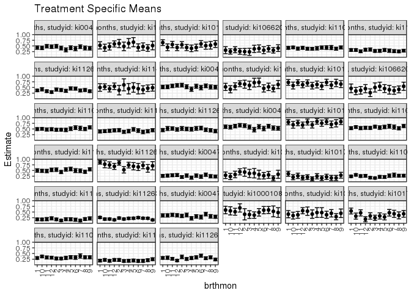

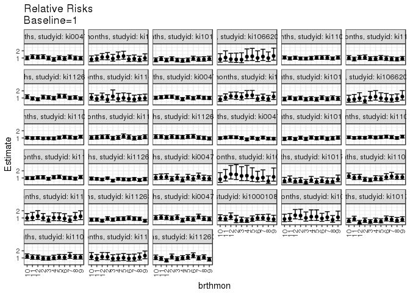

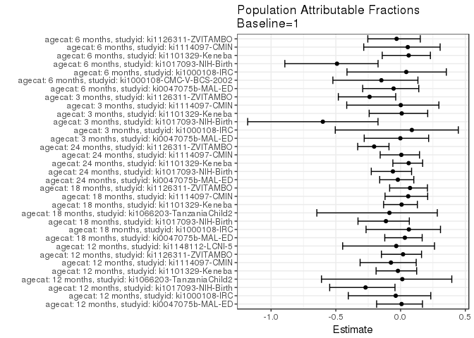

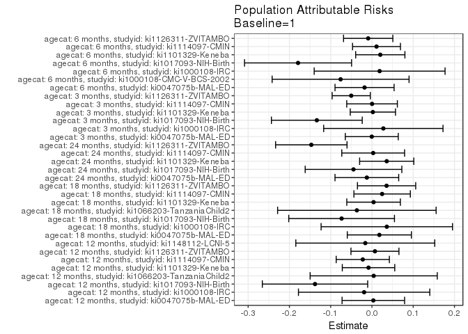

## Data Summary

| agecat | studyid | A | n | nA | nAY0 | nAY1 |
| --- | --- | --- | --- | --- | --- | --- |
| 3 months | ki0047075b-MAL-ED | 1 | 1868 | 180 | 133 | 47 |
| 3 months | ki0047075b-MAL-ED | 2 | 1868 | 174 | 137 | 37 |
| 3 months | ki0047075b-MAL-ED | 3 | 1868 | 145 | 105 | 40 |
| 3 months | ki0047075b-MAL-ED | 4 | 1868 | 119 | 97 | 22 |
| 3 months | ki0047075b-MAL-ED | 5 | 1868 | 139 | 101 | 38 |
| 3 months | ki0047075b-MAL-ED | 6 | 1868 | 117 | 90 | 27 |
| 3 months | ki0047075b-MAL-ED | 7 | 1868 | 156 | 107 | 49 |
| 3 months | ki0047075b-MAL-ED | 8 | 1868 | 138 | 104 | 34 |
| 3 months | ki0047075b-MAL-ED | 9 | 1868 | 165 | 126 | 39 |
| 3 months | ki0047075b-MAL-ED | 10 | 1868 | 175 | 127 | 48 |
| 3 months | ki0047075b-MAL-ED | 11 | 1868 | 179 | 127 | 52 |
| 3 months | ki0047075b-MAL-ED | 12 | 1868 | 181 | 127 | 54 |
| 3 months | ki1000108-CMC-V-BCS-2002 | 1 | 362 | 33 | 16 | 17 |
| 3 months | ki1000108-CMC-V-BCS-2002 | 2 | 362 | 15 | 12 | 3 |
| 3 months | ki1000108-CMC-V-BCS-2002 | 3 | 362 | 30 | 25 | 5 |
| 3 months | ki1000108-CMC-V-BCS-2002 | 4 | 362 | 43 | 35 | 8 |
| 3 months | ki1000108-CMC-V-BCS-2002 | 5 | 362 | 35 | 24 | 11 |
| 3 months | ki1000108-CMC-V-BCS-2002 | 6 | 362 | 35 | 22 | 13 |
| 3 months | ki1000108-CMC-V-BCS-2002 | 7 | 362 | 38 | 25 | 13 |
| 3 months | ki1000108-CMC-V-BCS-2002 | 8 | 362 | 17 | 11 | 6 |
| 3 months | ki1000108-CMC-V-BCS-2002 | 9 | 362 | 21 | 13 | 8 |
| 3 months | ki1000108-CMC-V-BCS-2002 | 10 | 362 | 29 | 19 | 10 |
| 3 months | ki1000108-CMC-V-BCS-2002 | 11 | 362 | 41 | 26 | 15 |
| 3 months | ki1000108-CMC-V-BCS-2002 | 12 | 362 | 25 | 9 | 16 |
| 3 months | ki1000108-IRC | 1 | 410 | 38 | 27 | 11 |
| 3 months | ki1000108-IRC | 2 | 410 | 28 | 16 | 12 |
| 3 months | ki1000108-IRC | 3 | 410 | 27 | 17 | 10 |
| 3 months | ki1000108-IRC | 4 | 410 | 21 | 13 | 8 |
| 3 months | ki1000108-IRC | 5 | 410 | 22 | 15 | 7 |
| 3 months | ki1000108-IRC | 6 | 410 | 37 | 27 | 10 |

[output cut: 870 more lines]

## Results Table

### Parameter: TSM

| agecat | studyid | intervention_level | baseline_level | estimate | ci_lower | ci_upper |
| --- | --- | --- | --- | --- | --- | --- |
| 3 months | ki0047075b-MAL-ED | 1 | NA | 0.2611111 | 0.1969266 | 0.3252956 |
| 3 months | ki0047075b-MAL-ED | 2 | NA | 0.2126437 | 0.1518299 | 0.2734574 |
| 3 months | ki0047075b-MAL-ED | 3 | NA | 0.2758621 | 0.2030946 | 0.3486295 |
| 3 months | ki0047075b-MAL-ED | 4 | NA | 0.1848739 | 0.1151084 | 0.2546395 |
| 3 months | ki0047075b-MAL-ED | 5 | NA | 0.2733813 | 0.1992683 | 0.3474943 |
| 3 months | ki0047075b-MAL-ED | 6 | NA | 0.2307692 | 0.1544052 | 0.3071332 |
| 3 months | ki0047075b-MAL-ED | 7 | NA | 0.3141026 | 0.2412462 | 0.3869589 |
| 3 months | ki0047075b-MAL-ED | 8 | NA | 0.2463768 | 0.1744647 | 0.3182889 |
| 3 months | ki0047075b-MAL-ED | 9 | NA | 0.2363636 | 0.1715217 | 0.3012056 |
| 3 months | ki0047075b-MAL-ED | 10 | NA | 0.2742857 | 0.2081662 | 0.3404052 |
| 3 months | ki0047075b-MAL-ED | 11 | NA | 0.2905028 | 0.2239773 | 0.3570283 |
| 3 months | ki0047075b-MAL-ED | 12 | NA | 0.2983425 | 0.2316703 | 0.3650148 |
| 3 months | ki1000108-IRC | 1 | NA | 0.2894737 | 0.1451023 | 0.4338451 |
| 3 months | ki1000108-IRC | 2 | NA | 0.4285714 | 0.2450478 | 0.6120950 |
| 3 months | ki1000108-IRC | 3 | NA | 0.3703704 | 0.1879988 | 0.5527420 |
| 3 months | ki1000108-IRC | 4 | NA | 0.3809524 | 0.1729989 | 0.5889058 |
| 3 months | ki1000108-IRC | 5 | NA | 0.3181818 | 0.1233145 | 0.5130491 |
| 3 months | ki1000108-IRC | 6 | NA | 0.2702703 | 0.1269995 | 0.4135411 |
| 3 months | ki1000108-IRC | 7 | NA | 0.3055556 | 0.1548980 | 0.4562131 |
| 3 months | ki1000108-IRC | 8 | NA | 0.1590909 | 0.0508854 | 0.2672964 |
| 3 months | ki1000108-IRC | 9 | NA | 0.3333333 | 0.1553045 | 0.5113621 |
| 3 months | ki1000108-IRC | 10 | NA | 0.2368421 | 0.1015030 | 0.3721812 |
| 3 months | ki1000108-IRC | 11 | NA | 0.3250000 | 0.1796745 | 0.4703255 |
| 3 months | ki1000108-IRC | 12 | NA | 0.4423077 | 0.3071514 | 0.5774640 |
| 3 months | ki1017093-NIH-Birth | 1 | NA | 0.3561644 | 0.2462271 | 0.4661016 |
| 3 months | ki1017093-NIH-Birth | 2 | NA | 0.2068966 | 0.1025637 | 0.3112294 |
| 3 months | ki1017093-NIH-Birth | 3 | NA | 0.1355932 | 0.0481662 | 0.2230202 |
| 3 months | ki1017093-NIH-Birth | 4 | NA | 0.2452830 | 0.1293569 | 0.3612092 |
| 3 months | ki1017093-NIH-Birth | 5 | NA | 0.1632653 | 0.0596947 | 0.2668359 |
| 3 months | ki1017093-NIH-Birth | 6 | NA | 0.2200000 | 0.1050875 | 0.3349125 |

[output cut: 366 more lines]

### Parameter: E(Y)

| agecat | studyid | intervention_level | baseline_level | estimate | ci_lower | ci_upper |
| --- | --- | --- | --- | --- | --- | --- |
| 3 months | ki0047075b-MAL-ED | NA | NA | 0.2607066 | 0.2591270 | 0.2622862 |
| 3 months | ki1000108-IRC | NA | NA | 0.3170732 | 0.3090739 | 0.3250724 |
| 3 months | ki1017093-NIH-Birth | NA | NA | 0.2225755 | 0.2175349 | 0.2276162 |
| 3 months | ki1101329-Keneba | NA | NA | 0.2447735 | 0.2430054 | 0.2465417 |
| 3 months | ki1114097-CMIN | NA | NA | 0.1759494 | 0.1745632 | 0.1773355 |
| 3 months | ki1126311-ZVITAMBO | NA | NA | 0.2098801 | 0.2087428 | 0.2110173 |
| 6 months | ki0047075b-MAL-ED | NA | NA | 0.3329519 | 0.3308360 | 0.3350679 |
| 6 months | ki1000108-CMC-V-BCS-2002 | NA | NA | 0.5122616 | 0.5029000 | 0.5216231 |
| 6 months | ki1000108-IRC | NA | NA | 0.4240196 | 0.4162719 | 0.4317673 |
| 6 months | ki1017093-NIH-Birth | NA | NA | 0.3647913 | 0.3562120 | 0.3733706 |
| 6 months | ki1101329-Keneba | NA | NA | 0.3228799 | 0.3216473 | 0.3241124 |
| 6 months | ki1114097-CMIN | NA | NA | 0.1996762 | 0.1985914 | 0.2007610 |
| 6 months | ki1126311-ZVITAMBO | NA | NA | 0.2965879 | 0.2943709 | 0.2988050 |
| 12 months | ki0047075b-MAL-ED | NA | NA | 0.4301775 | 0.4281028 | 0.4322522 |
| 12 months | ki1000108-IRC | NA | NA | 0.5073529 | 0.4998331 | 0.5148727 |
| 12 months | ki1017093-NIH-Birth | NA | NA | 0.5101664 | 0.5034371 | 0.5168957 |
| 12 months | ki1066203-TanzaniaChild2 | NA | NA | 0.3185484 | 0.3137895 | 0.3233073 |
| 12 months | ki1101329-Keneba | NA | NA | 0.4072987 | 0.4063318 | 0.4082655 |
| 12 months | ki1114097-CMIN | NA | NA | 0.2995575 | 0.2984343 | 0.3006807 |
| 12 months | ki1126311-ZVITAMBO | NA | NA | 0.3770621 | 0.3753134 | 0.3788107 |
| 12 months | ki1148112-LCNI-5 | NA | NA | 0.4838710 | 0.4785139 | 0.4892281 |
| 18 months | ki0047075b-MAL-ED | NA | NA | 0.5399381 | 0.5377803 | 0.5420958 |
| 18 months | ki1000108-IRC | NA | NA | 0.5623472 | 0.5530849 | 0.5716095 |
| 18 months | ki1017093-NIH-Birth | NA | NA | 0.6498994 | 0.6447809 | 0.6550179 |
| 18 months | ki1066203-TanzaniaChild2 | NA | NA | 0.4250000 | 0.4168583 | 0.4331417 |
| 18 months | ki1101329-Keneba | NA | NA | 0.4995622 | 0.4982093 | 0.5009150 |
| 18 months | ki1114097-CMIN | NA | NA | 0.4175210 | 0.4162069 | 0.4188351 |
| 18 months | ki1126311-ZVITAMBO | NA | NA | 0.4857297 | 0.4839378 | 0.4875215 |
| 24 months | ki0047075b-MAL-ED | NA | NA | 0.5876623 | 0.5850222 | 0.5903025 |
| 24 months | ki1017093-NIH-Birth | NA | NA | 0.7553191 | 0.7500544 | 0.7605839 |
| 24 months | ki1101329-Keneba | NA | NA | 0.5718169 | 0.5704749 | 0.5731590 |
| 24 months | ki1114097-CMIN | NA | NA | 0.5029970 | 0.5011879 | 0.5048061 |
| 24 months | ki1126311-ZVITAMBO | NA | NA | 0.7197452 | 0.7108997 | 0.7285907 |

### Parameter: RR

| agecat | studyid | intervention_level | baseline_level | estimate | ci_lower | ci_upper |
| --- | --- | --- | --- | --- | --- | --- |
| 3 months | ki0047075b-MAL-ED | 2 | 1 | 0.8143800 | 0.5585336 | 1.1874216 |
| 3 months | ki0047075b-MAL-ED | 3 | 1 | 1.0564930 | 0.7366760 | 1.5151539 |
| 3 months | ki0047075b-MAL-ED | 4 | 1 | 0.7080279 | 0.4512926 | 1.1108169 |
| 3 months | ki0047075b-MAL-ED | 5 | 1 | 1.0469922 | 0.7261297 | 1.5096376 |
| 3 months | ki0047075b-MAL-ED | 6 | 1 | 0.8837971 | 0.5852310 | 1.3346819 |
| 3 months | ki0047075b-MAL-ED | 7 | 1 | 1.2029460 | 0.8579592 | 1.6866525 |
| 3 months | ki0047075b-MAL-ED | 8 | 1 | 0.9435708 | 0.6442413 | 1.3819758 |
| 3 months | ki0047075b-MAL-ED | 9 | 1 | 0.9052224 | 0.6263007 | 1.3083613 |
| 3 months | ki0047075b-MAL-ED | 10 | 1 | 1.0504559 | 0.7444840 | 1.4821778 |
| 3 months | ki0047075b-MAL-ED | 11 | 1 | 1.1125639 | 0.7950997 | 1.5567839 |
| 3 months | ki0047075b-MAL-ED | 12 | 1 | 1.1425885 | 0.8196182 | 1.5928250 |
| 3 months | ki1000108-IRC | 2 | 1 | 1.4805195 | 0.7672366 | 2.8569256 |
| 3 months | ki1000108-IRC | 3 | 1 | 1.2794613 | 0.6348176 | 2.5787270 |
| 3 months | ki1000108-IRC | 4 | 1 | 1.3160173 | 0.6282630 | 2.7566504 |
| 3 months | ki1000108-IRC | 5 | 1 | 1.0991736 | 0.4989420 | 2.4214891 |
| 3 months | ki1000108-IRC | 6 | 1 | 0.9336609 | 0.4509137 | 1.9332363 |
| 3 months | ki1000108-IRC | 7 | 1 | 1.0555556 | 0.5234824 | 2.1284336 |
| 3 months | ki1000108-IRC | 8 | 1 | 0.5495868 | 0.2364546 | 1.2773939 |
| 3 months | ki1000108-IRC | 9 | 1 | 1.1515152 | 0.5545126 | 2.3912662 |
| 3 months | ki1000108-IRC | 10 | 1 | 0.8181818 | 0.3832229 | 1.7468201 |
| 3 months | ki1000108-IRC | 11 | 1 | 1.1227273 | 0.5746004 | 2.1937271 |
| 3 months | ki1000108-IRC | 12 | 1 | 1.5279720 | 0.8513239 | 2.7424327 |
| 3 months | ki1017093-NIH-Birth | 2 | 1 | 0.5809019 | 0.3216090 | 1.0492460 |
| 3 months | ki1017093-NIH-Birth | 3 | 1 | 0.3807040 | 0.1862653 | 0.7781137 |
| 3 months | ki1017093-NIH-Birth | 4 | 1 | 0.6886792 | 0.3916176 | 1.2110772 |
| 3 months | ki1017093-NIH-Birth | 5 | 1 | 0.4583987 | 0.2263900 | 0.9281743 |
| 3 months | ki1017093-NIH-Birth | 6 | 1 | 0.6176923 | 0.3367274 | 1.1330940 |
| 3 months | ki1017093-NIH-Birth | 7 | 1 | 0.4793621 | 0.2281729 | 1.0070786 |
| 3 months | ki1017093-NIH-Birth | 8 | 1 | 0.4793621 | 0.2281729 | 1.0070786 |
| 3 months | ki1017093-NIH-Birth | 9 | 1 | 0.8189103 | 0.4779509 | 1.4031023 |

[output cut: 333 more lines]

### Parameter: PAR

| agecat | studyid | intervention_level | baseline_level | estimate | ci_lower | ci_upper |
| --- | --- | --- | --- | --- | --- | --- |
| 3 months | ki0047075b-MAL-ED | 1 | NA | -0.0004045 | -0.0646084 | 0.0637995 |
| 3 months | ki1000108-IRC | 1 | NA | 0.0275995 | -0.1169934 | 0.1721923 |
| 3 months | ki1017093-NIH-Birth | 1 | NA | -0.1335889 | -0.2436416 | -0.0235361 |
| 3 months | ki1101329-Keneba | 1 | NA | 0.0022203 | -0.0526218 | 0.0570624 |
| 3 months | ki1114097-CMIN | 1 | NA | 0.0002737 | -0.0610701 | 0.0616175 |
| 3 months | ki1126311-ZVITAMBO | 1 | NA | -0.0502355 | -0.0964809 | -0.0039901 |
| 6 months | ki0047075b-MAL-ED | 1 | NA | -0.0179252 | -0.0895075 | 0.0536570 |
| 6 months | ki1000108-CMC-V-BCS-2002 | 1 | NA | -0.0759737 | -0.2418918 | 0.0899443 |
| 6 months | ki1000108-IRC | 1 | NA | 0.0186142 | -0.1399679 | 0.1771963 |
| 6 months | ki1017093-NIH-Birth | 1 | NA | -0.1790684 | -0.3087713 | -0.0493654 |
| 6 months | ki1101329-Keneba | 1 | NA | 0.0202483 | -0.0394082 | 0.0799048 |
| 6 months | ki1114097-CMIN | 1 | NA | 0.0111048 | -0.0468762 | 0.0690857 |
| 6 months | ki1126311-ZVITAMBO | 1 | NA | -0.0090889 | -0.0688113 | 0.0506334 |
| 12 months | ki0047075b-MAL-ED | 1 | NA | 0.0033482 | -0.0724025 | 0.0790990 |
| 12 months | ki1000108-IRC | 1 | NA | -0.0189628 | -0.1780893 | 0.1401636 |
| 12 months | ki1017093-NIH-Birth | 1 | NA | -0.1379818 | -0.2656475 | -0.0103161 |
| 12 months | ki1066203-TanzaniaChild2 | 1 | NA | 0.0042627 | -0.1497632 | 0.1582885 |
| 12 months | ki1101329-Keneba | 1 | NA | -0.0082858 | -0.0718589 | 0.0552874 |
| 12 months | ki1114097-CMIN | 1 | NA | -0.0222247 | -0.0866713 | 0.0422220 |
| 12 months | ki1126311-ZVITAMBO | 1 | NA | 0.0072507 | -0.0509103 | 0.0654118 |
| 12 months | ki1148112-LCNI-5 | 1 | NA | -0.0161290 | -0.1844887 | 0.1522307 |
| 18 months | ki0047075b-MAL-ED | 1 | NA | 0.0179255 | -0.0597708 | 0.0956218 |
| 18 months | ki1000108-IRC | 1 | NA | 0.0360314 | -0.1231864 | 0.1952492 |
| 18 months | ki1017093-NIH-Birth | 1 | NA | -0.0735049 | -0.2016189 | 0.0546092 |
| 18 months | ki1066203-TanzaniaChild2 | 1 | NA | -0.0365385 | -0.2285986 | 0.1555217 |
| 18 months | ki1101329-Keneba | 1 | NA | 0.0039481 | -0.0609786 | 0.0688748 |
| 18 months | ki1114097-CMIN | 1 | NA | 0.0246638 | -0.0437374 | 0.0930651 |
| 18 months | ki1126311-ZVITAMBO | 1 | NA | 0.0354679 | -0.0351311 | 0.1060669 |
| 24 months | ki0047075b-MAL-ED | 1 | NA | -0.0123377 | -0.0895316 | 0.0648563 |
| 24 months | ki1017093-NIH-Birth | 1 | NA | -0.0446809 | -0.1617934 | 0.0724317 |
| 24 months | ki1101329-Keneba | 1 | NA | 0.0357809 | -0.0298487 | 0.1014105 |
| 24 months | ki1114097-CMIN | 1 | NA | 0.0029970 | -0.0731049 | 0.0790989 |
| 24 months | ki1126311-ZVITAMBO | 1 | NA | -0.1469214 | -0.2334798 | -0.0603631 |

### Parameter: PAF

| agecat | studyid | intervention_level | baseline_level | estimate | ci_lower | ci_upper |
| --- | --- | --- | --- | --- | --- | --- |
| 3 months | ki0047075b-MAL-ED | 1 | NA | -0.0015514 | -0.2807399 | 0.2167768 |
| 3 months | ki1000108-IRC | 1 | NA | 0.0870445 | -0.5042690 | 0.4459185 |
| 3 months | ki1017093-NIH-Birth | 1 | NA | -0.6001957 | -1.1806557 | -0.1742460 |
| 3 months | ki1101329-Keneba | 1 | NA | 0.0090709 | -0.2423304 | 0.2095980 |
| 3 months | ki1114097-CMIN | 1 | NA | 0.0015555 | -0.4157092 | 0.2958361 |
| 3 months | ki1126311-ZVITAMBO | 1 | NA | -0.2393535 | -0.4805396 | -0.0374577 |
| 6 months | ki0047075b-MAL-ED | 1 | NA | -0.0538373 | -0.2923436 | 0.1406518 |
| 6 months | ki1000108-CMC-V-BCS-2002 | 1 | NA | -0.1483104 | -0.5227156 | 0.1340361 |
| 6 months | ki1000108-IRC | 1 | NA | 0.0438994 | -0.4137377 | 0.3533961 |
| 6 months | ki1017093-NIH-Birth | 1 | NA | -0.4908789 | -0.8936175 | -0.1737957 |
| 6 months | ki1101329-Keneba | 1 | NA | 0.0627115 | -0.1415152 | 0.2304003 |
| 6 months | ki1114097-CMIN | 1 | NA | 0.0556139 | -0.2843449 | 0.3055875 |
| 6 months | ki1126311-ZVITAMBO | 1 | NA | -0.0306450 | -0.2530375 | 0.1522767 |
| 12 months | ki0047075b-MAL-ED | 1 | NA | 0.0077834 | -0.1848998 | 0.1691333 |
| 12 months | ki1000108-IRC | 1 | NA | -0.0373760 | -0.4036281 | 0.2333090 |
| 12 months | ki1017093-NIH-Birth | 1 | NA | -0.2704643 | -0.5473137 | -0.0431496 |
| 12 months | ki1066203-TanzaniaChild2 | 1 | NA | 0.0133816 | -0.6105957 | 0.3956175 |
| 12 months | ki1101329-Keneba | 1 | NA | -0.0203432 | -0.1890001 | 0.1243901 |
| 12 months | ki1114097-CMIN | 1 | NA | -0.0741916 | -0.3123945 | 0.1207768 |
| 12 months | ki1126311-ZVITAMBO | 1 | NA | 0.0192296 | -0.1478064 | 0.1619574 |
| 12 months | ki1148112-LCNI-5 | 1 | NA | -0.0333333 | -0.4470409 | 0.2620957 |
| 18 months | ki0047075b-MAL-ED | 1 | NA | 0.0331992 | -0.1219557 | 0.1668978 |
| 18 months | ki1000108-IRC | 1 | NA | 0.0640732 | -0.2664685 | 0.3083453 |
| 18 months | ki1017093-NIH-Birth | 1 | NA | -0.1131019 | -0.3288092 | 0.0675894 |
| 18 months | ki1066203-TanzaniaChild2 | 1 | NA | -0.0859729 | -0.6465359 | 0.2837465 |
| 18 months | ki1101329-Keneba | 1 | NA | 0.0079032 | -0.1309608 | 0.1297169 |
| 18 months | ki1114097-CMIN | 1 | NA | 0.0590721 | -0.1198782 | 0.2094271 |
| 18 months | ki1126311-ZVITAMBO | 1 | NA | 0.0730198 | -0.0843333 | 0.2075386 |
| 24 months | ki0047075b-MAL-ED | 1 | NA | -0.0209945 | -0.1611801 | 0.1022670 |
| 24 months | ki1017093-NIH-Birth | 1 | NA | -0.0591549 | -0.2261512 | 0.0850972 |
| 24 months | ki1101329-Keneba | 1 | NA | 0.0625741 | -0.0595184 | 0.1705973 |
| 24 months | ki1114097-CMIN | 1 | NA | 0.0059583 | -0.1574590 | 0.1463033 |
| 24 months | ki1126311-ZVITAMBO | 1 | NA | -0.2041298 | -0.3309148 | -0.0894225 |